# STA 465 Homework 4

Tianyi Zhang 1005156607

11/04/2022

# Question 1: Sloths in Costa Rica

## Question 1.1

```r
grid
```

```
## class       : SpatialPolygonsDataFrame
## features    : 511
## extent      : -85.90801, -82.60801, 8.089453, 11.18945  (xmin, xmax, ymin, ymax)
## crs         : +proj=longlat +datum=WGS84 +no_defs +ellps=WGS84 +towgs84=0,0,0
## variables   : 6
## names       : layer,   id,  Y, cellarea,    cov,  id2
## min values  :     0,    3,  0,     0.01,     78,    3
## max values  :    96, 1021, 96,     0.01, 223.25, 1021
```

Looking at the `grid` dataset, we can see that it is of the SpatialPolygonsDataFrame class and its CRS is WGS84.

## Question 1.2

```r
#### Model 1; Weakly Informative Priors ####
# default values for priors for an rw2d and iid model are
# both log-gamma(1, 0.00005)
prior.weakly <- list(prec = list(prior = "normal",
                               param = c(1, 0.01)))

formula <- Y ~ 1 + cov +
  f(id, model="rw2d", nrow = nrow, ncol = ncol, hyper = prior.weakly) +
  f(id2, model="iid", hyper = prior.weakly)
res <- inla(formula, family = "poisson", data = grid@data,
    E = cellarea, control.predictor = list(compute = TRUE))

summary(res)
```

```
##
## Call:
##    c("inla.core(formula = formula, family = family, contrasts = contrasts,
##    ", " data = data, quantiles = quantiles, E = E, offset = offset, ", "
##    scale = scale, weights = weights, Ntrials = Ntrials, strata = strata,
##    ", " lp.scale = lp.scale, link.covariates = link.covariates, verbose =
##    verbose, ", " lincomb = lincomb, selection = selection, control.compute
##    = control.compute, ", " control.predictor = control.predictor,
##    control.family = control.family, ", " control.inla = control.inla,
##    control.fixed = control.fixed, ", " control.mode = control.mode,
##    control.expert = control.expert, ", " control.hazard = control.hazard,
##    control.lincomb = control.lincomb, ", " control.update =
##    control.update, control.lp.scale = control.lp.scale, ", "
##    control.pardiso = control.pardiso, only.hyperparam = only.hyperparam,
##    ", " inla.call = inla.call, inla.arg = inla.arg, num.threads =
##    num.threads, ", " blas.num.threads = blas.num.threads, keep = keep,
##    working.directory = working.directory, ", " silent = silent, inla.mode
##    = inla.mode, safe = FALSE, debug = debug, ", " .parent.frame =
##    .parent.frame)")
## Time used:
##     Pre = 1.15, Running = 15.3, Post = 0.0928, Total = 16.5
## Fixed effects:
##               mean    sd 0.025quant 0.5quant 0.975quant   mode kld
## (Intercept) -2.790 1.499     -5.899   -2.732     -0.006 -2.619   0
## cov          0.021 0.007      0.008    0.021      0.035  0.021   0
##
## Random effects:
##   Name     Model
##     id Random walk 2D
##    id2 IID model
##
## Model hyperparameters:
##                    mean    sd 0.025quant 0.5quant 0.975quant  mode
## Precision for id  0.346 0.173      0.126    0.308      0.786 0.246
## Precision for id2 0.235 0.053      0.146    0.230      0.354 0.221
##
## Marginal log-Likelihood:  -1639.59
## Posterior summaries for the linear predictor and the fitted values are computed
## (Posterior marginals needs also 'control.compute=list(return.marginals.predictor=TRUE)')
```

```r
#Organize Results in a Table
cred.int <- data.frame(LowerBound = res$summary.fixed$`0.025quant`,
                       UpperBound = res$summary.fixed$`0.975quant`,
                       Estimate = res$summary.fixed$mean)
rownames(cred.int)<- c("Intercept","Covariate")
cred.int %>%
  kable(
    caption = "95% Credible Intervals For Parameter Estimates,
      Weakly Informative Prior",
    col.names = c("Lower Bound", "Upper Bound", "Estimate"),
    row.names = TRUE,
    digits = 4,
    booktabs = TRUE
  )
```

95% Credible Intervals For Parameter Estimates, Weakly Informative Prior

|  | Lower Bound | Upper Bound | Estimate |
| --- | --- | --- | --- |
| Intercept | -5.8990 | -0.006 | -2.7896 |
| Covariate | 0.0081 | 0.035 | 0.0211 |

```r
#### Model 2; Non-Informative Priors ####
prior.non <- list(prec = list(prior = "loggamma",
                               param = c(1, 0.00001)))

formula <- Y ~ 1 + cov +
  f(id, model="rw2d", nrow = nrow, ncol = ncol, hyper = prior.non) +
  f(id2, model="iid", hyper = prior.non)
res2 <- inla(formula, family = "poisson", data = grid@data,
    E = cellarea, control.predictor = list(compute = TRUE))

summary(res2)
```

```
##
## Call:
##    c("inla.core(formula = formula, family = family, contrasts = contrasts,
##    ", " data = data, quantiles = quantiles, E = E, offset = offset, ", "
##    scale = scale, weights = weights, Ntrials = Ntrials, strata = strata,
##    ", " lp.scale = lp.scale, link.covariates = link.covariates, verbose =
##    verbose, ", " lincomb = lincomb, selection = selection, control.compute
##    = control.compute, ", " control.predictor = control.predictor,
##    control.family = control.family, ", " control.inla = control.inla,
##    control.fixed = control.fixed, ", " control.mode = control.mode,
##    control.expert = control.expert, ", " control.hazard = control.hazard,
##    control.lincomb = control.lincomb, ", " control.update =
##    control.update, control.lp.scale = control.lp.scale, ", "
##    control.pardiso = control.pardiso, only.hyperparam = only.hyperparam,
##    ", " inla.call = inla.call, inla.arg = inla.arg, num.threads =
##    num.threads, ", " blas.num.threads = blas.num.threads, keep = keep,
##    working.directory = working.directory, ", " silent = silent, inla.mode
##    = inla.mode, safe = FALSE, debug = debug, ", " .parent.frame =
##    .parent.frame)")
## Time used:
##     Pre = 0.419, Running = 15.6, Post = 0.143, Total = 16.2
## Fixed effects:
##               mean    sd 0.025quant 0.5quant 0.975quant   mode kld
## (Intercept) -2.563 1.425     -5.522   -2.507      0.077 -2.396   0
## cov          0.021 0.007      0.008    0.021      0.034  0.020   0
##
## Random effects:
##   Name     Model
##     id Random walk 2D
##    id2 IID model
##
## Model hyperparameters:
##                    mean    sd 0.025quant 0.5quant 0.975quant  mode
## Precision for id  0.464 0.268      0.151    0.398      1.160 0.300
## Precision for id2 0.236 0.053      0.146    0.231      0.354 0.222
##
## Marginal log-Likelihood:  -1658.67
## Posterior summaries for the linear predictor and the fitted values are computed
## (Posterior marginals needs also 'control.compute=list(return.marginals.predictor=TRUE)')
```

```r
#Organize Results in a Table
cred.int2 <- data.frame(LowerBound = res2$summary.fixed$`0.025quant`,
                       UpperBound = res2$summary.fixed$`0.975quant`,
                       Estimate = res2$summary.fixed$mean)
rownames(cred.int2)<- c("Intercept","Covariate")
cred.int2 %>%
  kable(
    caption = "95% Credible Intervals For Parameter Estimates,
      Non-Informative Prior",
    col.names = c("Lower Bound", "Upper Bound", "Estimate"),
    row.names = TRUE,
    digits = 4,
    booktabs = TRUE
  )
```

95% Credible Intervals For Parameter Estimates, Non-Informative Prior

|  | Lower Bound | Upper Bound | Estimate |
| --- | --- | --- | --- |
| Intercept | -5.5222 | 0.0775 | -2.5631 |
| Covariate | 0.0082 | 0.0340 | 0.0207 |

The tables show that the estimates and the 95% credible intervals for covariates in the weakly and non-informative priors are very similar. The 95% credible intervals and the estimates for the intercept in the model with weakly-informative prior is slightly lower in general.

## Quesiton 1.3

### Weakly Informative Model

The following maps are for the weakly informative model.

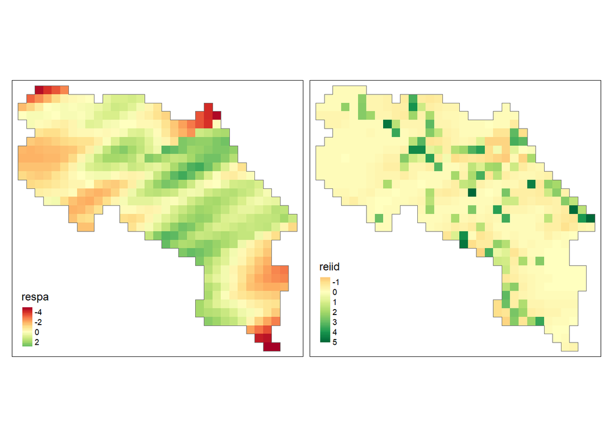

```r
#### Create maps of the random effects ####
# Weakly informative model
grid$respa <- res$summary.random$id[grid$id, "mean"]
grid$reiid <- res$summary.random$id2[, "mean"]

tm_shape(grid) +
  tm_polygons(col = c("respa", "reiid"), style = "cont", border.col = "transparent")  +
  tm_shape(gridborder) + tm_borders() +
  tm_facets(ncol = 2) + tm_legend(legend.position = c("left", "bottom"))
```

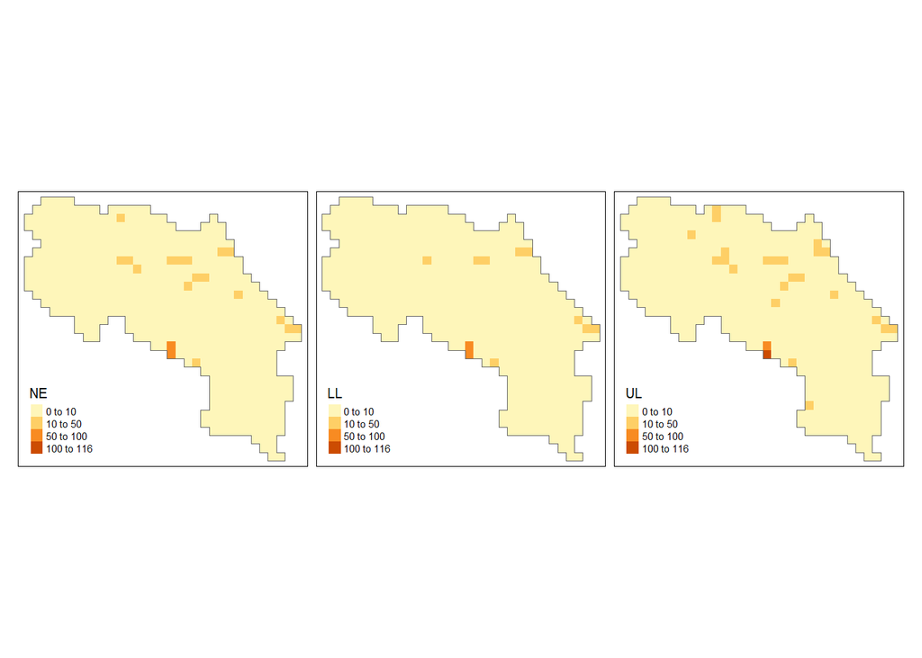

```r
# Predicted counts per cell
cellarea <- resolution*resolution
grid$NE <- res$summary.fitted.values[, "mean"] * cellarea
grid$LL <- res$summary.fitted.values[, "0.025quant"] * cellarea
grid$UL <- res$summary.fitted.values[, "0.975quant"] * cellarea
#summary(grid)

# Create maps for the predicted counts, its lower interval, and its upper
# interval respectively
# NE: map of predicted counts
# LL: map of lower limit
# UL: map of upper limit
tm_shape(grid) +
  tm_polygons(col = c("NE", "LL", "UL"),
              style = 'fixed', border.col = "transparent",
              breaks = c(0, 10, 50, 100, ceiling(max(grid$UL)))) +
  tm_shape(gridborder) + tm_borders() +
  tm_facets(ncol = 3) + tm_legend(legend.position = c("left", "bottom"))
```

The first two maps are maps of the random effects, rw2d and iid, respectively.

The next set of three maps are maps of the predicted counts per cell, its 95% lower limit and its upper limit, respectively.

### Non-Informative Model

The following maps are for the non-informative model.

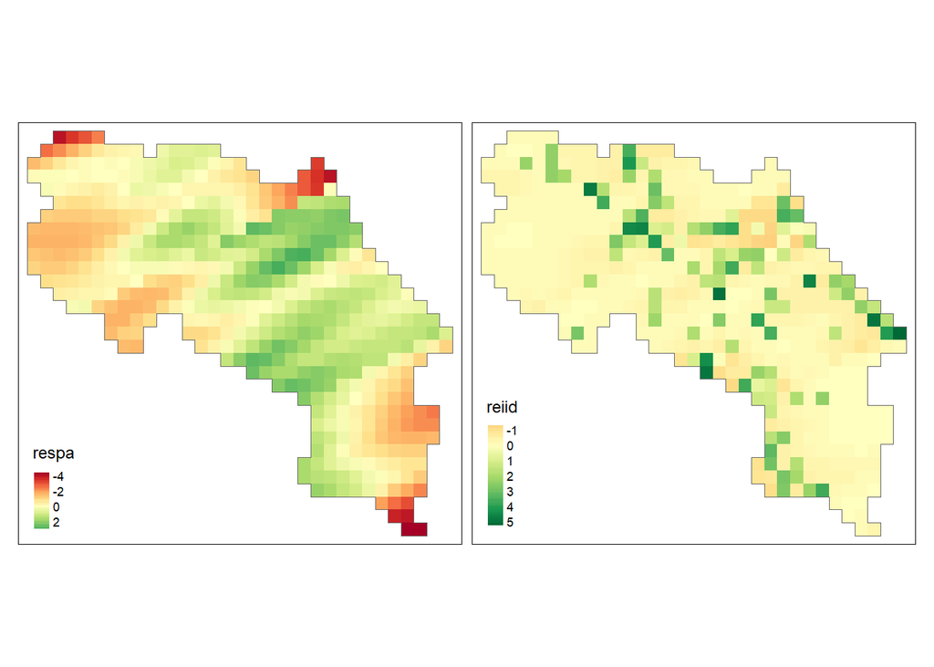

```r
#### Create maps of the random effects ####
# Non-informative model
grid$respa <- res2$summary.random$id[grid$id, "mean"]
grid$reiid <- res2$summary.random$id2[, "mean"]

tm_shape(grid) +
  tm_polygons(col = c("respa", "reiid"), style = "cont", border.col = "transparent")  +
  tm_shape(gridborder) + tm_borders() +
  tm_facets(ncol = 2) + tm_legend(legend.position = c("left", "bottom"))
```

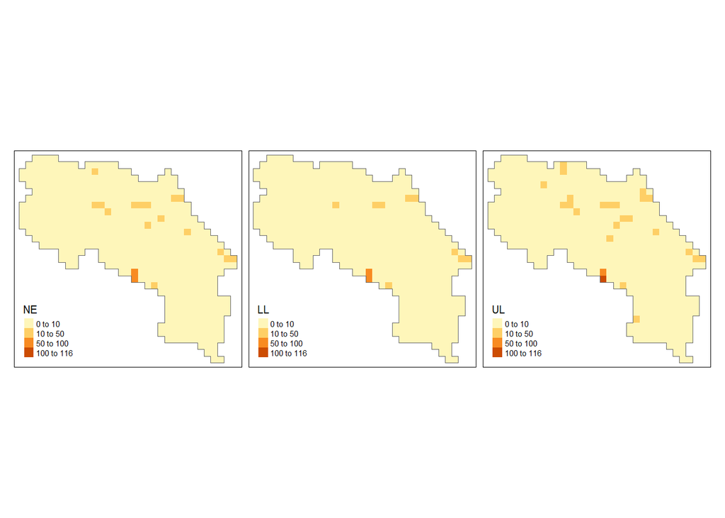

```r
# Predicted counts per cell
cellarea <- resolution*resolution
grid$NE <- res2$summary.fitted.values[, "mean"] * cellarea
grid$LL <- res2$summary.fitted.values[, "0.025quant"] * cellarea
grid$UL <- res2$summary.fitted.values[, "0.975quant"] * cellarea
#summary(grid)

# Create maps for the predicted counts, its lower interval, and its upper
# interval respectively
# NE: map of predicted counts
# LL: map of lower limit
# UL: map of upper limit
tm_shape(grid) +
  tm_polygons(col = c("NE", "LL", "UL"),
              style = 'fixed', border.col = "transparent",
              breaks = c(0, 10, 50, 100, ceiling(max(grid$UL)))) +
  tm_shape(gridborder) + tm_borders() +
  tm_facets(ncol = 3) + tm_legend(legend.position = c("left", "bottom"))
```

The first two maps are maps of the random effects, rw2d and iid, respectively.

The next set of three maps are maps of the predicted counts per cell, its 95% lower limit and its upper limit, respectively.

There does not seem to be any major differences in the predicted cell counts and its 95% credible intervals for the weakly informative prior and non-informative prior.

# Question 2

## Question 2.1

```r
#### Get data ####
# Data acquisition code is from Lab 5
library(SpatialEpi)
library(sf)
library(spdep)

data(pennLC)
population <- pennLC$data$population
cases <- pennLC$data$cases
n.strata <- 16
E <- expected(population, cases, n.strata)
d <- aggregate(x = pennLC$data$cases, by = list(county = pennLC$data$county), FUN = sum)

# convert from spatial polygon to simple feature
pennLC.sf <- st_as_sf(pennLC$spatial.polygon)
pennLC.sf$county <- d$county
pennLC.sf$counts <- d$x
pennLC.sf$E <- E[match(pennLC.sf$county, unique(pennLC$data$county))]
pennLC.sf <- merge(pennLC.sf, pennLC$smoking, by.x = "county", by.y = "county")
pennLC.sf <- pennLC.sf%>%
  mutate(SIR = counts/E)

#### Fit models ####
# Using Default Priors
##### Complete pooling and smoking covariate (no random effect) #####
formula.2.1.1 <- counts ~ 1 + smoking
res.2.1.1 <- inla(formula.2.1.1, family = "poisson", data = pennLC.sf,
            E = pennLC.sf$E, control.predictor = list(compute = TRUE),
            control.compute = list(cpo=TRUE))

##### Hierarchical random effect (iid) - (intercept only) #####
formula.2.1.2 <- counts ~ 1 + f(county, model = "iid")
res.2.1.2 <- inla(formula.2.1.2, family = "poisson", data = pennLC.sf,
            E = pennLC.sf$E, control.predictor = list(compute = TRUE),
            control.compute = list(cpo=TRUE))

##### Hierarchical random effect (iid) + smoking covariate #####
# add a column of numbers (need both intercept and slope to vary)
pennLC.sf$county_dup <- pennLC.sf$county
formula.2.1.3 <- counts ~ 1 + smoking + f(county, model = "iid") +
  f(county_dup, smoking, model = "iid")
res.2.1.3 <- inla(formula.2.1.3, family = "poisson", data = pennLC.sf,
            E = pennLC.sf$E, control.predictor = list(compute = TRUE),
            control.compute = list(cpo=TRUE))

##### Spatial + iid random effect #####
# use BYM for spatial random effect
## Values of E_i and neighborhood structure
E.penn <- pennLC.sf$E
neighbor.penn <- poly2nb(pennLC.sf)

nb2INLA("npenn.adj", neighbor.penn)
g <- inla.read.graph(filename = "npenn.adj")

pennLC.sf$re_u <- 1:nrow(pennLC.sf)
pennLC.sf$re_v <- 1:nrow(pennLC.sf)

formula.2.1.4 <- counts ~ 1 + f(re_u, model = "besag", graph = g) +
  f(re_v, model = "iid")
res.2.1.4 <- inla(formula.2.1.4, family = "poisson", data = pennLC.sf,
            E = pennLC.sf$E, control.predictor = list(compute = TRUE),
            control.compute = list(cpo=TRUE))

##### Spatial + iid random effect + smoking covariate #####
formula.2.1.5 <- counts ~ smoking + f(re_u, model = "besag", graph = g) +
  f(re_v, model = "iid")
res.2.1.5 <- inla(formula.2.1.5, family = "poisson", data = pennLC.sf,
            E = pennLC.sf$E, control.predictor = list(compute = TRUE),
            control.compute = list(cpo=TRUE))
```

### 2.1.1: Complete pooling and smoking covariate (no random effect)

```r
#### Make a table of CPO and PIT values ####
cpo.2.1.1 <- data.frame(CPO = res.2.1.1$cpo$cpo,
                       PIT = res.2.1.1$cpo$pit)
cpo.2.1.1 %>%
  kable(
    caption = "CPO and PIT values for Complete Pooling and Smoking
    Covariate (no random effect)",
    row.names = FALSE,
    digits = 4,
    booktabs = TRUE,
    align = 'l'
  )
```

CPO and PIT values for Complete Pooling and Smoking Covariate (no random effect)

| CPO | PIT |
| --- | --- |
| 0.0113 | 0.0467 |
| 0.0005 | 0.9939 |
| 0.0023 | 0.0074 |
| 0.0210 | 0.2171 |
| 0.0394 | 0.1842 |
| 0.0221 | 0.5737 |
| 0.0153 | 0.9114 |
| 0.0473 | 0.6924 |
| 0.0016 | 0.9875 |
| 0.0138 | 0.9077 |
| 0.0010 | 0.0046 |
| 0.0974 | 0.8638 |
| 0.0132 | 0.0489 |
| 0.0103 | 0.0443 |
| 0.0225 | 0.5715 |
| 0.0685 | 0.4574 |
| 0.0464 | 0.5551 |
| 0.0303 | 0.1081 |
| 0.0325 | 0.8555 |
| 0.0365 | 0.2749 |
| 0.0014 | 0.0068 |
| 0.0067 | 0.0462 |
| 0.0016 | 0.9870 |
| 0.0713 | 0.5504 |
| 0.0252 | 0.5589 |
| 0.0157 | 0.8952 |
| 0.1639 | 0.3889 |
| 0.0358 | 0.3719 |
| 0.1180 | 0.5192 |
| 0.0423 | 0.8482 |
| 0.0164 | 0.0503 |
| 0.0457 | 0.4219 |
| 0.0314 | 0.1280 |
| 0.0005 | 0.0008 |
| 0.0025 | 0.0148 |
| 0.0018 | 0.0138 |
| 0.0034 | 0.0140 |
| 0.0034 | 0.0137 |
| 0.0244 | 0.4490 |
| 0.0024 | 0.0180 |
| 0.0284 | 0.2247 |
| 0.0522 | 0.2740 |
| 0.0051 | 0.0251 |
| 0.0442 | 0.8065 |
| 0.0201 | 0.8825 |
| 0.0014 | 0.9838 |
| 0.0162 | 0.0306 |
| 0.0124 | 0.8934 |
| 0.0397 | 0.3636 |
| 0.0687 | 0.6518 |
| 0.0000 | 1.0000 |
| 0.0525 | 0.2768 |
| 0.0405 | 0.9135 |
| 0.0167 | 0.1277 |
| 0.0747 | 0.5799 |
| 0.0016 | 0.0051 |
| 0.0325 | 0.0487 |
| 0.0655 | 0.4327 |
| 0.0196 | 0.0644 |
| 0.0722 | 0.4404 |
| 0.0059 | 0.9830 |
| 0.0569 | 0.3211 |
| 0.0243 | 0.7264 |
| 0.0584 | 0.6064 |
| 0.0112 | 0.8695 |
| 0.0212 | 0.0512 |
| 0.0206 | 0.3181 |

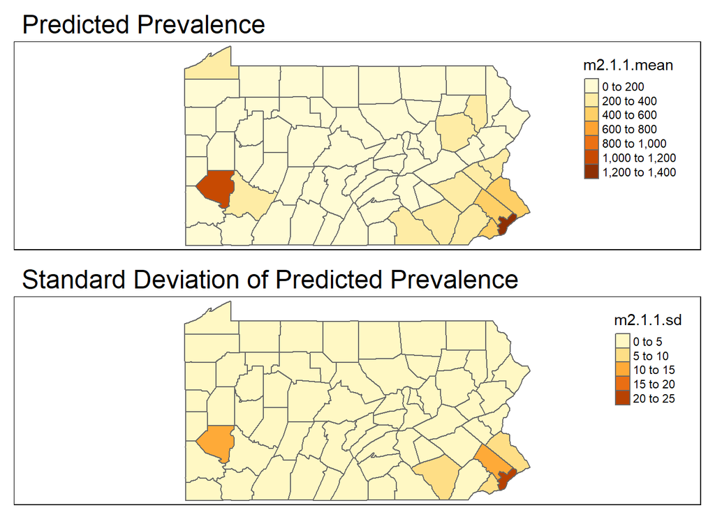

```r
#### Create maps of predicted prevalence and its standard deviation ####
pennLC.sf$m2.1.1.mean <- res.2.1.1$summary.fitted.values[,"mean"]*E.penn
pennLC.sf$m2.1.1.sd <- res.2.1.1$summary.fitted.values[,"sd"]*E.penn

res.2.1.1.mean <- tm_shape(pennLC.sf) +
  tm_polygons("m2.1.1.mean") +
  tm_layout(main.title = "Predicted Prevalence")

res.2.1.1.sd <- tm_shape(pennLC.sf) +
  tm_polygons("m2.1.1.sd") +
  tm_layout(main.title = "Standard Deviation of Predicted Prevalence")

tmap_arrange(res.2.1.1.mean, res.2.1.1.sd, ncol=1)
```

### 2.1.2: Hierarchical random effect (iid) - (intercept only)

```r
#### Make a table of CPO and PIT values ####
cpo.2.1.2 <- data.frame(CPO = res.2.1.2$cpo$cpo,
                       PIT = res.2.1.2$cpo$pit)
cpo.2.1.2 %>%
  kable(
    caption = "CPO and PIT values for Hierarchical random effect (iid)
    - (intercept only)",
    row.names = FALSE,
    digits = 4,
    booktabs = TRUE,
    align = 'l'
  )
```

CPO and PIT values for Hierarchical random effect (iid) - (intercept only)

| CPO | PIT |
| --- | --- |
| 0.0206 | 0.1258 |
| 0.0013 | 0.9060 |
| 0.0108 | 0.0512 |
| 0.0182 | 0.6417 |
| 0.0431 | 0.2617 |
| 0.0097 | 0.7412 |
| 0.0132 | 0.8758 |
| 0.0282 | 0.8364 |
| 0.0051 | 0.8446 |
| 0.0050 | 0.9571 |
| 0.0096 | 0.0916 |
| 0.0916 | 0.8707 |
| 0.0206 | 0.1019 |
| 0.0141 | 0.0834 |
| 0.0124 | 0.5510 |
| 0.0619 | 0.5108 |
| 0.0357 | 0.6061 |
| 0.0511 | 0.2586 |
| 0.0315 | 0.8054 |
| 0.0355 | 0.6006 |
| 0.0046 | 0.0405 |
| 0.0101 | 0.1365 |
| 0.0043 | 0.8646 |
| 0.0629 | 0.5918 |
| 0.0094 | 0.8424 |
| 0.0125 | 0.8603 |
| 0.1665 | 0.4120 |
| 0.0280 | 0.5089 |
| 0.1139 | 0.5636 |
| 0.0357 | 0.8542 |
| 0.0243 | 0.0908 |
| 0.0369 | 0.5959 |
| 0.0374 | 0.1945 |
| 0.0011 | 0.0017 |
| 0.0145 | 0.2587 |
| 0.0054 | 0.1106 |
| 0.0215 | 0.1777 |
| 0.0071 | 0.0433 |
| 0.0140 | 0.5512 |
| 0.0117 | 0.3592 |
| 0.0295 | 0.5486 |
| 0.0517 | 0.3458 |
| 0.0234 | 0.2683 |
| 0.0368 | 0.8124 |
| 0.0160 | 0.8609 |
| 0.0063 | 0.6129 |
| 0.0185 | 0.0368 |
| 0.0099 | 0.8243 |
| 0.0312 | 0.3872 |
| 0.0621 | 0.6227 |
| 0.0002 | 0.9876 |
| 0.0526 | 0.3577 |
| 0.0258 | 0.9489 |
| 0.0217 | 0.3818 |
| 0.0672 | 0.5673 |
| 0.0091 | 0.0447 |
| 0.0511 | 0.0811 |
| 0.0595 | 0.5000 |
| 0.0408 | 0.1896 |
| 0.0649 | 0.4418 |
| 0.0025 | 0.9919 |
| 0.0545 | 0.3901 |
| 0.0147 | 0.7323 |
| 0.0481 | 0.6529 |
| 0.0062 | 0.8398 |
| 0.0395 | 0.1154 |
| 0.0129 | 0.5366 |

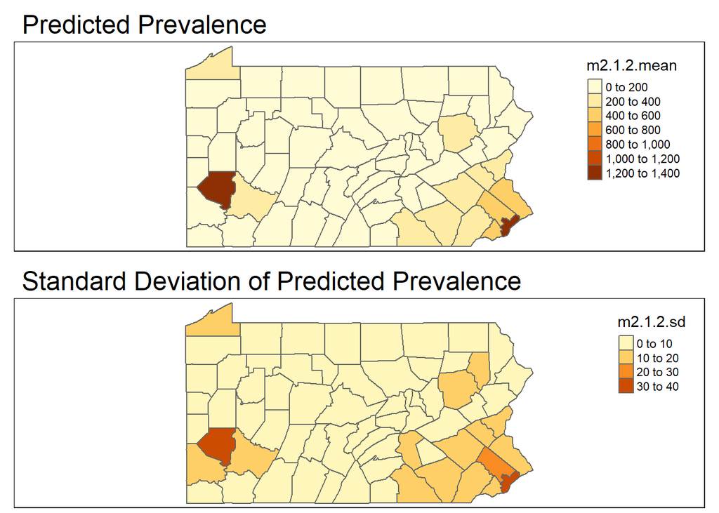

```r
#### Create maps of predicted prevalence and its standard deviation ####
pennLC.sf$m2.1.2.mean <- res.2.1.2$summary.fitted.values[,"mean"]*E.penn
pennLC.sf$m2.1.2.sd <- res.2.1.2$summary.fitted.values[,"sd"]*E.penn

res.2.1.2.mean <- tm_shape(pennLC.sf) +
  tm_polygons("m2.1.2.mean") +
  tm_layout(main.title = "Predicted Prevalence")

res.2.1.2.sd <- tm_shape(pennLC.sf) +
  tm_polygons("m2.1.2.sd") +
  tm_layout(main.title = "Standard Deviation of Predicted Prevalence")

tmap_arrange(res.2.1.2.mean, res.2.1.2.sd, ncol=1)
```

### 2.1.3: Hierarchical random effect (iid) + smoking covariate

```r
#### Make a table of CPO and PIT values ####
cpo.2.1.3 <- data.frame(CPO = res.2.1.3$cpo$cpo,
                       PIT = res.2.1.3$cpo$pit)
cpo.2.1.3 %>%
  kable(
    caption = "CPO and PIT values for Hierarchical random effect (iid)
    + smoking covariate",
    row.names = FALSE,
    digits = 4,
    booktabs = TRUE,
    align = 'l'
  )
```

CPO and PIT values for Hierarchical random effect (iid) + smoking covariate

| CPO | PIT |
| --- | --- |
| 0.0210 | 0.1266 |
| 0.0015 | 0.8969 |
| 0.0087 | 0.0393 |
| 0.0192 | 0.4894 |
| 0.0451 | 0.2779 |
| 0.0107 | 0.7022 |
| 0.0119 | 0.8968 |
| 0.0337 | 0.7752 |
| 0.0033 | 0.9185 |
| 0.0082 | 0.9189 |
| 0.0076 | 0.0671 |
| 0.0893 | 0.8772 |
| 0.0224 | 0.1124 |
| 0.0181 | 0.1142 |
| 0.0119 | 0.6519 |
| 0.0626 | 0.5339 |
| 0.0356 | 0.6374 |
| 0.0429 | 0.1972 |
| 0.0263 | 0.8581 |
| 0.0355 | 0.4664 |
| 0.0069 | 0.0652 |
| 0.0131 | 0.1944 |
| 0.0031 | 0.9180 |
| 0.0629 | 0.6145 |
| 0.0127 | 0.7311 |
| 0.0115 | 0.8801 |
| 0.1687 | 0.4214 |
| 0.0286 | 0.5191 |
| 0.1143 | 0.5678 |
| 0.0343 | 0.8658 |
| 0.0258 | 0.0972 |
| 0.0379 | 0.5568 |
| 0.0396 | 0.2090 |
| 0.0012 | 0.0019 |
| 0.0113 | 0.1700 |
| 0.0076 | 0.1744 |
| 0.0132 | 0.0923 |
| 0.0098 | 0.0630 |
| 0.0141 | 0.5989 |
| 0.0099 | 0.2478 |
| 0.0289 | 0.4323 |
| 0.0536 | 0.3669 |
| 0.0160 | 0.1498 |
| 0.0352 | 0.8301 |
| 0.0149 | 0.8786 |
| 0.0035 | 0.8578 |
| 0.0222 | 0.0450 |
| 0.0088 | 0.8598 |
| 0.0332 | 0.4720 |
| 0.0594 | 0.6871 |
| 0.0005 | 0.9679 |
| 0.0540 | 0.3721 |
| 0.0315 | 0.9322 |
| 0.0210 | 0.3347 |
| 0.0663 | 0.6254 |
| 0.0072 | 0.0335 |
| 0.0433 | 0.0675 |
| 0.0603 | 0.5163 |
| 0.0324 | 0.1374 |
| 0.0671 | 0.5008 |
| 0.0044 | 0.9841 |
| 0.0562 | 0.4124 |
| 0.0143 | 0.7604 |
| 0.0479 | 0.6712 |
| 0.0065 | 0.8387 |
| 0.0328 | 0.0917 |
| 0.0132 | 0.5411 |

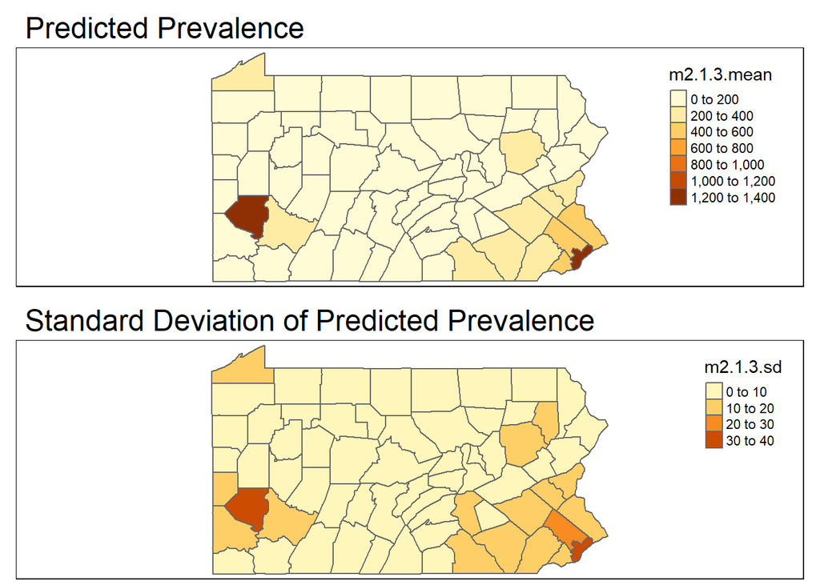

```r
#### Create maps of predicted prevalence and its standard deviation ####
pennLC.sf$m2.1.3.mean <- res.2.1.3$summary.fitted.values[,"mean"]*E.penn
pennLC.sf$m2.1.3.sd <- res.2.1.3$summary.fitted.values[,"sd"]*E.penn

res.2.1.3.mean <- tm_shape(pennLC.sf) +
  tm_polygons("m2.1.3.mean") +
  tm_layout(main.title = "Predicted Prevalence")

res.2.1.3.sd <- tm_shape(pennLC.sf) +
  tm_polygons("m2.1.3.sd") +
  tm_layout(main.title = "Standard Deviation of Predicted Prevalence")

tmap_arrange(res.2.1.3.mean, res.2.1.3.sd, ncol=1)
```

### 2.1.4: Spatial + iid random effect

```r
#### Make a table of CPO and PIT values ####
cpo.2.1.4 <- data.frame(CPO = res.2.1.4$cpo$cpo,
                       PIT = res.2.1.4$cpo$pit)
cpo.2.1.4 %>%
  kable(
    caption = "CPO and PIT values for Spatial + iid random effect",
    row.names = FALSE,
    digits = 4,
    booktabs = TRUE,
    align = 'l'
  )
```

CPO and PIT values for Spatial + iid random effect

| CPO | PIT |
| --- | --- |
| 0.0321 | 0.2247 |
| 0.0021 | 0.8868 |
| 0.0042 | 0.0156 |
| 0.0218 | 0.4323 |
| 0.0513 | 0.3225 |
| 0.0083 | 0.8794 |
| 0.0056 | 0.9681 |
| 0.0207 | 0.9103 |
| 0.0099 | 0.6442 |
| 0.0053 | 0.9667 |
| 0.0081 | 0.0586 |
| 0.0901 | 0.8781 |
| 0.0172 | 0.0736 |
| 0.0160 | 0.0848 |
| 0.0152 | 0.4689 |
| 0.0634 | 0.4389 |
| 0.0392 | 0.6730 |
| 0.0563 | 0.2778 |
| 0.0238 | 0.8963 |
| 0.0385 | 0.4653 |
| 0.0087 | 0.0725 |
| 0.0187 | 0.2442 |
| 0.0086 | 0.6508 |
| 0.0668 | 0.5878 |
| 0.0108 | 0.7728 |
| 0.0170 | 0.8112 |
| 0.1630 | 0.3906 |
| 0.0251 | 0.7777 |
| 0.1137 | 0.6366 |
| 0.0465 | 0.7544 |
| 0.0310 | 0.1151 |
| 0.0409 | 0.6118 |
| 0.0344 | 0.1574 |
| 0.0015 | 0.0023 |
| 0.0164 | 0.2437 |
| 0.0072 | 0.1170 |
| 0.0129 | 0.0830 |
| 0.0097 | 0.0564 |
| 0.0182 | 0.4466 |
| 0.0163 | 0.4216 |
| 0.0326 | 0.6757 |
| 0.0512 | 0.3053 |
| 0.0156 | 0.1251 |
| 0.0251 | 0.9093 |
| 0.0127 | 0.9207 |
| 0.0077 | 0.2684 |
| 0.0212 | 0.0425 |
| 0.0124 | 0.8081 |
| 0.0391 | 0.5391 |
| 0.0563 | 0.7649 |
| 0.0007 | 0.9606 |
| 0.0495 | 0.3284 |
| 0.0210 | 0.9633 |
| 0.0289 | 0.4818 |
| 0.0668 | 0.6764 |
| 0.0060 | 0.0253 |
| 0.0545 | 0.0865 |
| 0.0624 | 0.5470 |
| 0.0416 | 0.1891 |
| 0.0711 | 0.5218 |
| 0.0022 | 0.9941 |
| 0.0511 | 0.2975 |
| 0.0209 | 0.4880 |
| 0.0485 | 0.6925 |
| 0.0082 | 0.8635 |
| 0.0431 | 0.1247 |
| 0.0074 | 0.8906 |

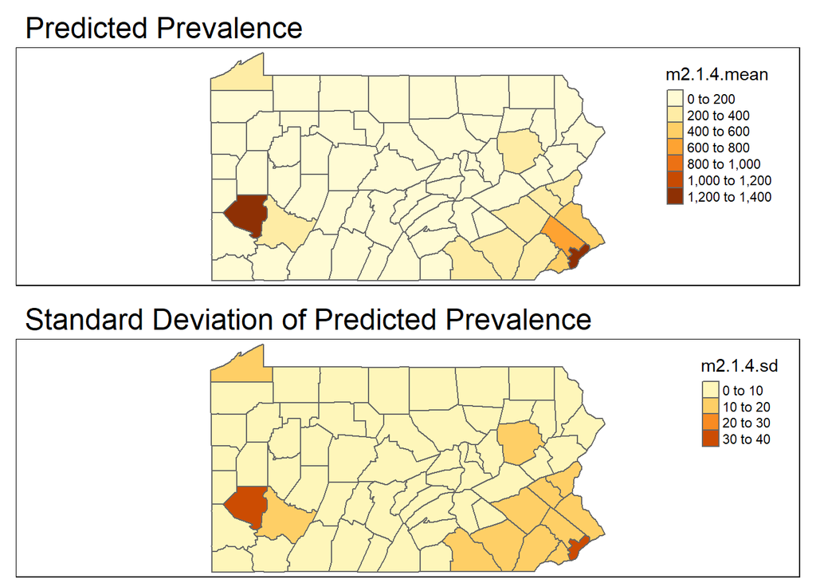

```r
#### Create maps of predicted prevalence and its standard deviation ####
pennLC.sf$m2.1.4.mean <- res.2.1.4$summary.fitted.values[,"mean"]*E.penn
pennLC.sf$m2.1.4.sd <- res.2.1.4$summary.fitted.values[,"sd"]*E.penn

res.2.1.4.mean <- tm_shape(pennLC.sf) +
  tm_polygons("m2.1.4.mean") +
  tm_layout(main.title = "Predicted Prevalence")

res.2.1.4.sd <- tm_shape(pennLC.sf) +
  tm_polygons("m2.1.4.sd") +
  tm_layout(main.title = "Standard Deviation of Predicted Prevalence")

tmap_arrange(res.2.1.4.mean, res.2.1.4.sd, ncol=1)
```

### 2.1.5: Spatial + iid random effect + smoking covariate

```r
#### Make a table of CPO and PIT values ####
cpo.2.1.5 <- data.frame(CPO = res.2.1.5$cpo$cpo,
                       PIT = res.2.1.5$cpo$pit)
cpo.2.1.5 %>%
  kable(
    caption = "CPO and PIT values for
    Spatial + iid random effect + smoking covariate",
    row.names = FALSE,
    digits = 4,
    booktabs = TRUE,
    align = 'l'
  )
```

CPO and PIT values for Spatial + iid random effect + smoking covariate

| CPO | PIT |
| --- | --- |
| 0.0301 | 0.1981 |
| 0.0017 | 0.9218 |
| 0.0039 | 0.0143 |
| 0.0198 | 0.3203 |
| 0.0526 | 0.3344 |
| 0.0123 | 0.7710 |
| 0.0049 | 0.9738 |
| 0.0260 | 0.8753 |
| 0.0083 | 0.7698 |
| 0.0080 | 0.9446 |
| 0.0059 | 0.0395 |
| 0.0864 | 0.8874 |
| 0.0188 | 0.0817 |
| 0.0211 | 0.1208 |
| 0.0158 | 0.4947 |
| 0.0655 | 0.5014 |
| 0.0376 | 0.7138 |
| 0.0479 | 0.2143 |
| 0.0175 | 0.9332 |
| 0.0376 | 0.4043 |
| 0.0113 | 0.1000 |
| 0.0210 | 0.2957 |
| 0.0081 | 0.7200 |
| 0.0659 | 0.6308 |
| 0.0127 | 0.7128 |
| 0.0151 | 0.8498 |
| 0.1682 | 0.4126 |
| 0.0272 | 0.7476 |
| 0.1144 | 0.6300 |
| 0.0448 | 0.7794 |
| 0.0314 | 0.1165 |
| 0.0419 | 0.5820 |
| 0.0389 | 0.1866 |
| 0.0015 | 0.0022 |
| 0.0127 | 0.1598 |
| 0.0092 | 0.1605 |
| 0.0095 | 0.0559 |
| 0.0117 | 0.0693 |
| 0.0186 | 0.4430 |
| 0.0136 | 0.2704 |
| 0.0349 | 0.5486 |
| 0.0554 | 0.3535 |
| 0.0120 | 0.0877 |
| 0.0251 | 0.9107 |
| 0.0110 | 0.9366 |
| 0.0082 | 0.6222 |
| 0.0254 | 0.0518 |
| 0.0119 | 0.8292 |
| 0.0382 | 0.6175 |
| 0.0528 | 0.7958 |
| 0.0019 | 0.8266 |
| 0.0520 | 0.3526 |
| 0.0255 | 0.9525 |
| 0.0275 | 0.3846 |
| 0.0645 | 0.7133 |
| 0.0046 | 0.0186 |
| 0.0481 | 0.0754 |
| 0.0624 | 0.5884 |
| 0.0354 | 0.1496 |
| 0.0713 | 0.5763 |
| 0.0032 | 0.9908 |
| 0.0569 | 0.3676 |
| 0.0211 | 0.5796 |
| 0.0470 | 0.7247 |
| 0.0075 | 0.8840 |
| 0.0385 | 0.1078 |
| 0.0096 | 0.8451 |

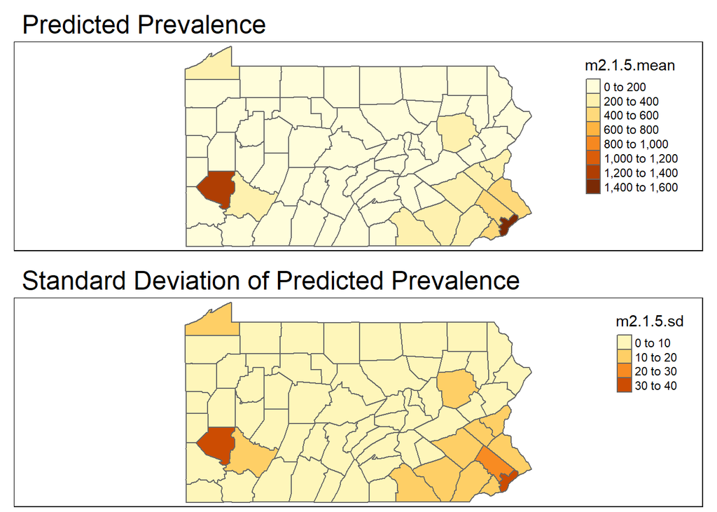

```r
#### Create maps of predicted prevalence and its standard deviation ####
pennLC.sf$m2.1.5.mean <- res.2.1.5$summary.fitted.values[,"mean"]*E.penn
pennLC.sf$m2.1.5.sd <- res.2.1.5$summary.fitted.values[,"sd"]*E.penn

res.2.1.5.mean <- tm_shape(pennLC.sf) +
  tm_polygons("m2.1.5.mean") +
  tm_layout(main.title = "Predicted Prevalence")

res.2.1.5.sd <- tm_shape(pennLC.sf) +
  tm_polygons("m2.1.5.sd") +
  tm_layout(main.title = "Standard Deviation of Predicted Prevalence")

tmap_arrange(res.2.1.5.mean, res.2.1.5.sd, ncol=1)
```

There does not seem to be any major difference between the predicted prevalence between all five models; The two counties with the highest prevalence of lung cancer always seems to be Allegheny and Philadelphia.

In the spatial + iid random effect model (2.1.4), the estimated prevalence in Montgomery is relatively higher when compared to the other models.

## Question 2.2

```r
#### Organize Results in a Table: Estimates and Credible Intervals ####
##### 2.2.1: Complete pooling and smoking covariate (no random effects) #####
table.2.2.1 <- data.frame(LowerLimit = res.2.1.1$summary.fixed$`0.025quant`,
                       UpperLimit = res.2.1.1$summary.fixed$`0.975quant`,
                       Estimate = res.2.1.1$summary.fixed$mean)
rownames(table.2.2.1)<- c("Model 1 Intercept","Model 1 Covariate")

##### 2.2.2: Hierarchical random effect (iid) - (intercept only) #####
table.2.2.2 <- data.frame(LowerLimit = res.2.1.2$summary.fixed$`0.025quant`,
                       UpperLimit = res.2.1.2$summary.fixed$`0.975quant`,
                       Estimate = res.2.1.2$summary.fixed$mean)
rownames(table.2.2.2)<- c("Model 2 Intercept")

##### 2.2.3: Hierarchical random effect (iid) + smoking covariate #####
table.2.2.3 <- data.frame(LowerLimit = res.2.1.3$summary.fixed$`0.025quant`,
                       UpperLimit = res.2.1.3$summary.fixed$`0.975quant`,
                       Estimate = res.2.1.3$summary.fixed$mean)
rownames(table.2.2.3)<- c("Model 3 Intercept","Model 3 Covariate")

##### 2.2.4: Spatial + iid random effect #####
table.2.2.4 <- data.frame(LowerLimit = res.2.1.4$summary.fixed$`0.025quant`,
                       UpperLimit = res.2.1.4$summary.fixed$`0.975quant`,
                       Estimate = res.2.1.4$summary.fixed$mean)
rownames(table.2.2.4)<- c("Model 4 Intercept")

##### 2.2.5: Spatial + iid random effect #####
table.2.2.5 <- data.frame(LowerLimit = res.2.1.5$summary.fixed$`0.025quant`,
                       UpperLimit = res.2.1.5$summary.fixed$`0.975quant`,
                       Estimate = res.2.1.5$summary.fixed$mean)
rownames(table.2.2.5)<- c("Model 5 Intercept","Model 5 Covariate")

##### Merge all tables #####
table.2.2 <- bind_rows(table.2.2.1, table.2.2.2, table.2.2.3, table.2.2.4,
                       table.2.2.5)
table.2.2 %>%
  kable(
    caption = "Parameter Estimates and 95% Credible Intervals For All 5 Models",
    col.names = c("Lower Bound", "Upper Bound", "Estimate"),
    row.names = TRUE,
    digits = 4,
    booktabs = TRUE
  )
```

Parameter Estimates and 95% Credible Intervals For All 5 Models

|  | Lower Bound | Upper Bound | Estimate |
| --- | --- | --- | --- |
| Model 1 Intercept | -0.5468 | -0.2001 | -0.3732 |
| Model 1 Covariate | 0.8427 | 2.2808 | 1.5617 |
| Model 2 Intercept | -0.0824 | -0.0105 | -0.0451 |
| Model 3 Intercept | -0.6404 | -0.0006 | -0.3187 |
| Model 3 Covariate | -0.1813 | 2.4920 | 1.1569 |
| Model 4 Intercept | -0.0771 | -0.0199 | -0.0481 |
| Model 5 Intercept | -0.6206 | -0.0278 | -0.3233 |
| Model 5 Covariate | -0.0808 | 2.3836 | 1.1552 |

```r
#### Organize Results in a Table: Sum of Log(CPO) ####
sum_cpo1 <- sum(log(res.2.1.1$cpo$cpo))
sum_cpo2 <- sum(log(res.2.1.2$cpo$cpo))
sum_cpo3 <- sum(log(res.2.1.3$cpo$cpo))
sum_cpo4 <- sum(log(res.2.1.4$cpo$cpo))
sum_cpo5 <- sum(log(res.2.1.5$cpo$cpo))

sum_cpo <- t(data.frame(sum_cpo1, sum_cpo2, sum_cpo3, sum_cpo4, sum_cpo5))
rownames(sum_cpo) <- c("Model 1", "Model 2", "Model 3", "Model 4", "Model 5")

sum_cpo %>%
  kable(
    caption = "Sum of Log(CPO) for All 5 Models",
    col.names = "Sum of Log(CPO)",
    row.names = TRUE,
  )
```

Sum of Log(CPO) for All 5 Models

|  | Sum of Log(CPO) |
| --- | --- |
| Model 1 | -287.9617 |
| Model 2 | -267.3142 |
| Model 3 | -266.9735 |
| Model 4 | -263.0463 |
| Model 5 | -261.9201 |

A smaller value of $-\sum log(CPO)$ points to a better model fit. Therefore, Model 5, Spatial + iid random effect + smoking covariate, is the model with the best fit.

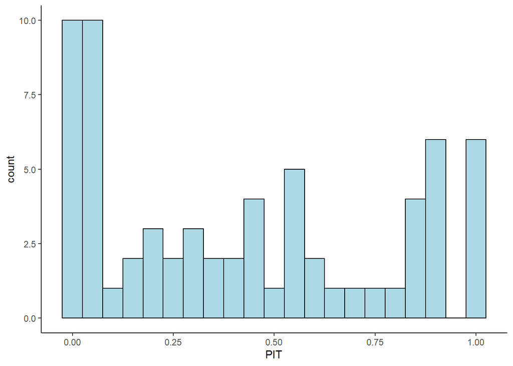

```r
#### Plot Histogram of the PIT values ####
##### Model 1: Complete pooling and smoking covariate (no random effects) #####
pit1 <- data.frame(PIT = res.2.1.1$cpo$pit)

ggplot(data = pit1, aes(x=PIT)) +
  geom_histogram(binwidth=0.05, color="black", fill="lightblue") +
  theme_classic()
```

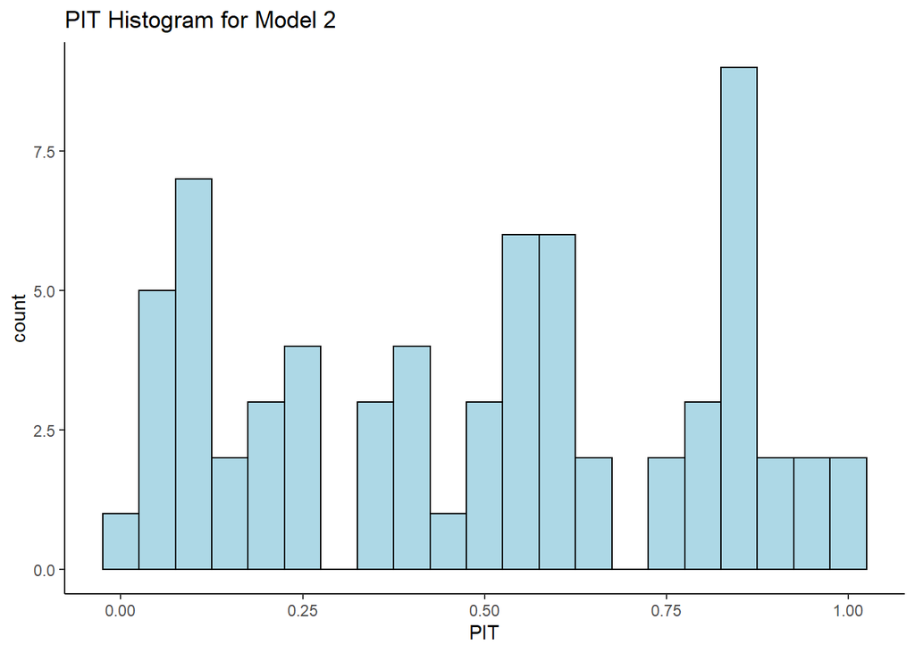

```r
##### Model 2: Hierarchical random effect (iid) - (intercept only) #####
pit2 <- data.frame(PIT = res.2.1.2$cpo$pit)

ggplot(data = pit2, aes(x=PIT)) +
  geom_histogram(binwidth=0.05, color="black", fill="lightblue") +
  labs(title="PIT Histogram for Model 2") +
  theme_classic()
```

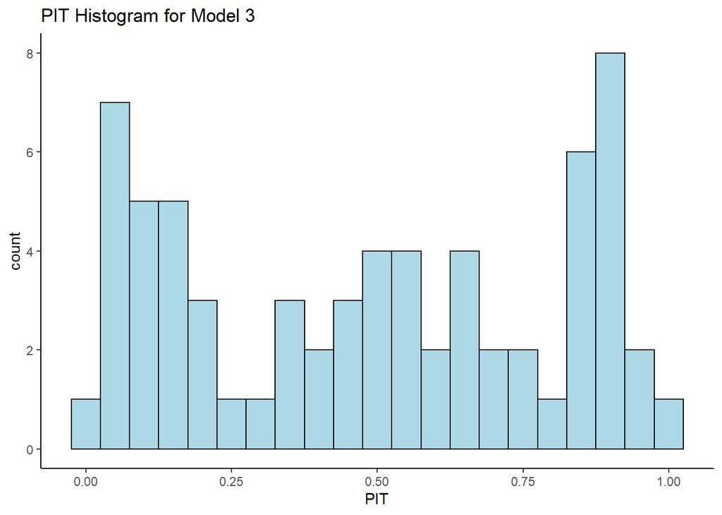

```r
##### Model 3: Hierarchical random effect (iid) + smoking covariate #####
pit3 <- data.frame(PIT = res.2.1.3$cpo$pit)

ggplot(data = pit3, aes(x=PIT)) +
  geom_histogram(binwidth=0.05, color="black", fill="lightblue") +
  labs(title="PIT Histogram for Model 3") +
  theme_classic()
```

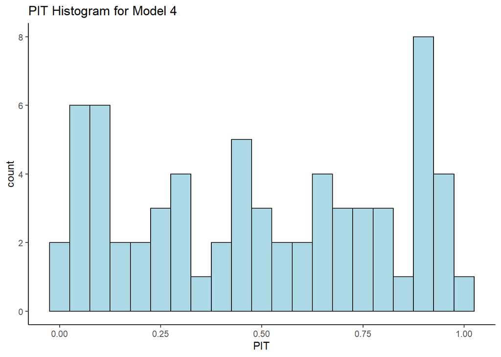

```r
##### Model 4: Spatial + iid random effect #####
pit4 <- data.frame(PIT = res.2.1.4$cpo$pit)

ggplot(data = pit4, aes(x=PIT)) +
  geom_histogram(binwidth=0.05, color="black", fill="lightblue") +
  labs(title="PIT Histogram for Model 4") +
  theme_classic()
```

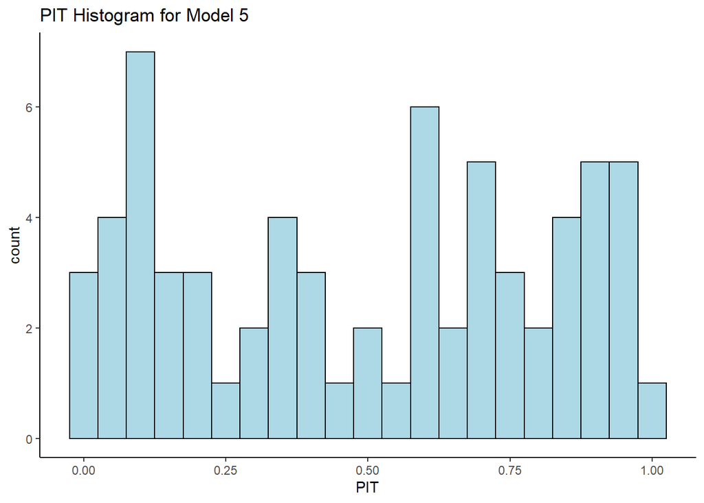

```r
##### Model 4: Spatial + iid random effect + smoking covariate #####
pit5 <- data.frame(PIT = res.2.1.5$cpo$pit)

ggplot(data = pit5, aes(x=PIT)) +
  geom_histogram(binwidth=0.05, color="black", fill="lightblue") +
  labs(title="PIT Histogram for Model 5") +
  theme_classic()
```

In general, if the model represents the observations well, we should see a uniform distribution in the histogram of PIT values. By looking at the PIT histograms for each model, we see that Model 4 and Model 5 have a relatively uniform distribution when compared to the other models. Therefore, the histograms of PIT values tell us that Model 4 and Model 5 represent the observations the best.

# Question 3

```r
#### Setup ####
## load in the R packages needed and data
library(geoR)
library(rgdal)
library(geodist)

data(gambia)

## aggregate by location and convert the object into a 'sf' object
d <- group_by(gambia, x, y) %>%
  summarize(
    total = n(),
    positive = sum(pos),
    prev = positive / total
  )

sps <- SpatialPoints(d[, c("x", "y")],
  proj4string = CRS("+proj=utm +zone=28")
)
spst <- spTransform(sps, CRS("+proj=longlat +datum=WGS84"))
d[,c("long", "lat")] <- spst@coords
r <- getData(name = "alt", country = "GMB", mask = TRUE)
d$alt <- raster::extract(r, d[, c("long", "lat")])

## Find and fill the missing altitudes
r_sen <- getData(name = "alt", country = "SEN", mask = TRUE)

sen_alt <- raster::extract(r_sen, d[, c("long", "lat")])

d$alt[25] <- 31
d$alt[64] <- 20

gambia.sf <- st_as_sf(d, coords = c("long", "lat"), crs = "+proj=longlat +datum=WGS84")

## map of the prevalence data
tmap_mode("view")
tm_shape(gambia.sf) + tm_dots("prev", title = "Prevalence")
```

[interactive chart not shown]

From the map, we can see that the prevalence data is generally split into four secitons based on their geographical location. The points are concentrated near one of four regions: Kerewan, Brikama, JanJan Bureh, and Basse. Therefore, we will partition the data into 4 folds based on these regions.

```r
#### Perform 4-fold CV ####
## Model: Spatial + iid random effect + altitude covariate
gambia.sf$id <- 1:nrow(gambia.sf)
gambia.sf$id2 <- 1:nrow(gambia.sf)

formula <- prev ~ 1 + alt +
  f(id, model = "rw2d", nrow = nrow, ncol = ncol) +
  f(id2, model = "iid")

##### Parition the points based on Coordinates #####
# partition for Kerewan
part1 <- filter(gambia.sf, x > 363790 & x < 397080 & y > 1490500 & y < 1502000)
# partition for Brikama
part2 <- filter(gambia.sf, x > 349600 & x < 390500 & y > 1458000 & y < 1466500)
# partition for JanJan Bureh
part3 <- filter(gambia.sf, x > 486500 & x < 524000 & y > 1485000 & y < 1515000)
# partition for Basse
part4 <- filter(gambia.sf, x > 572000 & x < 622500 & y > 1467000 & y < 1500000)

tm_shape(part1) + tm_dots("prev", col = "red") +
  tm_layout(title = "Kerewan Partition")
```

[interactive chart not shown]

```r
tm_shape(part2) + tm_dots("prev", col = "lightblue") +
  tm_layout(title = "Brikama Partition")
```

[interactive chart not shown]

```r
tm_shape(part3) + tm_dots("prev", col = "green") +
  tm_layout(title = "JanJan Bureh Partition")
```

[interactive chart not shown]

```r
tm_shape(part4) + tm_dots("prev", col = "yellow") +
  tm_layout(title = "Basse Partition")
```

[interactive chart not shown]

The four maps above showcase the geographically partitioned folds. A 4-fold CV is performed and the mean squared error (MSE) in each process is shown in the table below:

```r
#### Repeat process four times ####
##### First time #####
# To predict points in Kerewan region, set the prev of points in the said region
# to NA
N <- nrow(part1)
pred1 <- gambia.sf %>%
  filter(x > 363790 & x < 397080 & y > 1490500 & y < 1502000) %>%
  mutate(prev = NA) %>%
  bind_rows(part2,part3,part4)

res.3.1 <- inla(formula, family = "gaussian", data = pred1,
                control.predictor = list(compute = TRUE))

pred_mean.3.1 <- res.3.1$summary.fitted.values[1:N, "mean"]
# Calculate MSE
MSE.3.1 <- sum((part1$prev - pred_mean.3.1)^2)/N

##### Second time #####
N <- nrow(part2)
pred2 <- gambia.sf %>%
  filter(x > 349600 & x < 390500 & y > 1458000 & y < 1466500) %>%
  mutate(prev = NA) %>%
  bind_rows(part1,part3,part4)

res.3.2 <- inla(formula, family = "gaussian", data = pred2,
                control.predictor = list(compute = TRUE))

pred_mean.3.2 <- res.3.2$summary.fitted.values[1:N, "mean"]
# Calculate MSE
MSE.3.2 <- sum((part2$prev - pred_mean.3.2)^2)/N

##### Third time #####
N <- nrow(part3)
pred3 <- gambia.sf %>%
  filter(x > 486500 & x < 524000 & y > 1485000 & y < 1515000) %>%
  mutate(prev = NA) %>%
  bind_rows(part1,part2,part4)

res.3.3 <- inla(formula, family = "gaussian", data = pred3,
                control.predictor = list(compute = TRUE))

pred_mean.3.3 <- res.3.3$summary.fitted.values[1:N, "mean"]
# Calculate MSE
MSE.3.3 <- sum((part3$prev - pred_mean.3.3)^2)/N

##### Fourth time #####
N <- nrow(part4)
pred4 <- gambia.sf %>%
  filter(x > 572000 & x < 622500 & y > 1467000 & y < 1500000) %>%
  mutate(prev = NA) %>%
  bind_rows(part1,part2,part3)

res.3.4 <- inla(formula, family = "gaussian", data = pred4,
                control.predictor = list(compute = TRUE))

pred_mean.3.4 <- res.3.4$summary.fitted.values[1:N, "mean"]
# Calculate MSE
MSE.3.4 <- sum((part4$prev - pred_mean.3.4)^2)/N

#### Create a table for the MSE ####
MSEs <- data.frame(MSE1 = MSE.3.1, MSE2 = MSE.3.2,
                   MSE3 = MSE.3.3, MSE4 = MSE.3.4)
MSEs %>%
  kable(
    caption = "Mean Squared Error in each repetition for 4-fold CV",
    col.names = c("MSE-Kere","MSE-Brik","MSE-JanJan","MSE-Basse"),
    row.names = FALSE,
    digits = 4,
    booktabs = TRUE
  )
```

Mean Squared Error in each repetition for 4-fold CV

| MSE-Kere | MSE-Brik | MSE-JanJan | MSE-Basse |
| --- | --- | --- | --- |
| 0.0342 | 0.0787 | 0.0803 | 0.2154 |

# References

- Gómez-Rubio, V. (2021, August 29). Bayesian inference with INLA. Chapter 5 Priors in R-INLA. Retrieved April 12, 2022, from https://becarioprecario.bitbucket.io/inla-gitbook/ch-priors.html
- Moraga, P. (n.d.). Geospatial Health Data: Modeling and visualization with R-INLA and shiny. Chapter 4 The R-INLA package. Retrieved April 12, 2022, from https://www.paulamoraga.com/book-geospatial/sec-inla.html?q=cross#model
- Moraga, P. (n.d.). Species Distribution Modeling using Spatial Point Processes: a Case Study of Sloths in Costa Rica. Species distribution modeling using Spatial Point Processes: A case study of sloths in Costa Rica. Retrieved April 12, 2022, from https://www.paulamoraga.com/tutorial-point-patterns/#54_Fitting_the_model_using_INLA
- Rue, H., Lindgren, F., Niekerk, J. van, Krainski, E., & Fattah, E. A. (n.d.). INLA Project - FAQ. R-INLA Project. Retrieved April 12, 2022, from https://www.r-inla.org/faq#h.821k2r53fvx3
- Asidianya, N, (2022, February 16) Lab Lecture #5. Quercus. https://q.utoronto.ca/
- Barajas, V. Leos, (2022, April 1) Lecture11 [PDF]. Quercus. https://q.utoronto.ca/